# task2_ABCDdraft

Kalpa Rashmikah, Zhuoyan Jiang

2026-10-17

#Task 2

$$\mu_1,\mu_2\overset{\mathrm{ind}}{\sim}N(m_0,s_0^2)$$
The standardized observations have a sample mean of $0$ and a sample variance of $1$. So we choose $m_0 = 0$, because the observations are centred around zero after standardization.

The prior standard deviation $s_0$ have to choose how widely we think the component means can vary around $m_0$. For example, suppose we believe that the component means lie within the interval $[-10,10]$. We can choose $s_0 = 5$, giving the prior distribution $\mu_1,\mu_2 \overset{\mathrm{ind}}{\sim} N(0,5^2)$ For a normal distribution, the approximate 95% prior interval is
$$\begin{aligned}
[m_0 - 1.96s_0,\; m_0 + 1.96s_0]
&= [0 - 1.96(5),\; 0 + 1.96(5)] \\
&= [-9.80,\; 9.80].
\end{aligned}$$
Therefore, this prior assigns approximately 95% probability to each component mean being between $-9.80$ and $9.80$.
$$\pi\sim\operatorname{Beta}(a,b)$$
$0<\pi<1$, therefore all values have to be between 0 and 1. if the prior distribution is beta, then the obvious choice is ${Beta}(1,1)$, which is a uniform prior.

$$\sigma^2\sim\operatorname{InvGamma}(\alpha_0,\beta_0)$$
Because the standardized data have overall variance 1, by taking $\sigma^2\sim\operatorname{InvGamma}(2,1)$, which means $\alpha_0=2$ and $\beta_0=1$, gives $E(\sigma^2)=1$
$$E(\sigma^2)=\frac{\beta_0}{\alpha_0-1}=\frac{1}{2-1}=1$$
Also, with shape 2, the inverse-Gamma distribution has substantial uncertainty, including a heavy right tail.

#Part A: Latent-variable representation and Gibbs sampler

1. Conditional distribution of $Z_i$

Objective is to find the full conditional distribution of $Z_i$, given $y_i$, $\mu_1$, $\mu_2$, $\pi$, and $\sigma^2$.

The two-component Gaussian mixture model is

$$Y_i\mid Z_i=k\sim N(\mu_k,\sigma^2),
\qquad k\in\{1,2\}$$

Therefore, for component 1,

$$Y_i\mid Z_i=1\sim N(\mu_1,\sigma^2)$$
$$P(Z_i=1)=\pi$$

and for component 2,

$$Y_i\mid Z_i=2\sim N(\mu_2,\sigma^2)$$
$$P(Z_i=2)=1-\pi$$

Using the multiplication rule,

$$f(y_i,z_i)=f(y_i\mid z_i)P(Z_i=z_i)$$

if $Z_i = 1$:
$$f(y_i,z_i=1)=\pi f_1(y_i)
\tag{1}$$

if $Z_i = 2$:
$$f(y_i,z_i=2)=(1-\pi)f_2(y_i)
\tag{2}$$

For $n$ observations, let $n_1$ denote the number of observations allocated to component 1 and $n_2$ denote the number allocated to component 2.

Then,

$$n_1+n_2=n$$

Complete likelihood
$$f(y,z)
=
\pi^{n_1}(1-\pi)^{n_2}
\prod_{i:z_i=1}f_1(y_i)
\prod_{i:z_i=2}f_2(y_i)$$

From Bayes’ theorem,
$$P(Z_i=1\mid y_i)
=
\frac{f(y_i,Z_i=1)}{f(y_i)}
\tag{3}$$

Total probability,
$$\begin{aligned}
f(y_i)
&=f(y_i,Z_i=1)+f(y_i,Z_i=2)\\
&=\pi f_1(y_i)+(1-\pi)f_2(y_i)
\end{aligned}
\tag{4}$$

Substituting (1) and (4) into (3),

$$\boxed{
P(Z_i=1\mid y_i)
=
\frac{\pi f_1(y_i)}
{\pi f_1(y_i)+(1-\pi)f_2(y_i)}
}$$

Similarly,

$$\boxed{
P(Z_i=2\mid y_i)
=
\frac{(1-\pi)f_2(y_i)}
{\pi f_1(y_i)+(1-\pi)f_2(y_i)}
}$$

2. Conditional distribution of $\mu_1$ and $\mu_2$

First, consider the conditional distribution of $\mu_1$.

Objective is to find

$$f(\mu_1\mid y,z,\sigma^2)$$

The prior distribution is

$$\mu_1\sim N(m_0,s_0^2)$$

From Bayes’ theorem,
$$f(\mu_1\mid y,z,\sigma^2)
\propto
f(y\mid z,\mu_1,\sigma^2)f(\mu_1)
\tag{5}$$

The normal prior density is
$$f(\mu_1)
=
\frac{1}{\sqrt{2\pi_{\mathrm{math}}s_0^2}}
\exp\left(
-\frac{(\mu_1-m_0)^2}{2s_0^2}
\right)$$
Ignoring constants that do not depend on $\mu_1$,
$$f(\mu_1)
\propto
\exp\left(
-\frac{(\mu_1-m_0)^2}{2s_0^2}
\right)
\tag{6}$$

The likelihood contains only observations allocated to component 1.

Therefore,

$$f(y\mid z,\mu_1,\sigma^2)
\propto
\prod_{i:z_i=1}
\exp\left(
-\frac{(y_i-\mu_1)^2}{2\sigma^2}
\right)$$
$$f(y\mid z,\mu_1,\sigma^2)
\propto
\exp\left(
-\frac{\sum_{i:z_i=1}(y_i-\mu_1)^2}
{2\sigma^2}
\right)
\tag{7}$$

Substituting (6) and (7) into (5),

$$f(\mu_1\mid y,z,\sigma^2)
\propto
\exp\left(
-\frac{\sum_{i:z_i=1}(y_i-\mu_1)^2}
{2\sigma^2}
\right)
\times
\exp\left(
-\frac{(\mu_1-m_0)^2}{2s_0^2}
\right)$$

Combining the exponential terms,

$$f(\mu_1\mid y,z,\sigma^2)
\propto
\exp\left[
-\frac12
\left(
\frac{\sum_{i:z_i=1}(y_i-\mu_1)^2}{\sigma^2}
+
\frac{(\mu_1-m_0)^2}{s_0^2}
\right)
\right]$$

Expanding the squared terms,

$$\begin{aligned}
\sum_{i:z_i=1}(y_i-\mu_1)^2
&=
\sum_{i:z_i=1}y_i^2
-2\mu_1\sum_{i:z_i=1}y_i
+n_1\mu_1^2
\end{aligned}$$

and

$$(\mu_1-m_0)^2
=
\mu_1^2-2\mu_1m_0+m_0^2$$

Removing terms that do not depend on $\mu_1$,

$$f(\mu_1\mid y,z,\sigma^2)
\propto
\exp\Bigg[
-\left(
\frac{n_1}{2\sigma^2}
+\frac{1}{2s_0^2}
\right)\mu_1^2
+
\left(
\frac{\sum_{i:z_i=1}y_i}{\sigma^2}
+\frac{m_0}{s_0^2}
\right)\mu_1
\Bigg]
\tag{8}$$

Normal density can be written as
$$\begin{aligned}
f(x)
&\propto
\exp\left(
-\frac{(x-m)^2}{2v}
\right)
\\
&\propto
\exp\left(
-\frac{x^2-2xm+m^2}{2v}
\right)
\end{aligned}$$
$$f(x)
\propto
\exp\left(
-\frac{x^2}{2v}+\frac{m}{v}x
\right)
\tag{9}$$

Comparing (8) and (9), we obtain

$$\frac{1}{2v_1}
=
\frac{n_1}{2\sigma^2}
+
\frac{1}{2s_0^2}$$

Therefore,

$$\boxed{
v_1=
\left(
\frac{n_1}{\sigma^2}
+
\frac{1}{s_0^2}
\right)^{-1}
}$$

Similarly,

$$\frac{m_1}{v_1}
=
\frac{\sum_{i:z_i=1}y_i}{\sigma^2}
+
\frac{m_0}{s_0^2}$$

Therefore,

$$\boxed{
m_1=
v_1
\left(
\frac{\sum_{i:z_i=1}y_i}{\sigma^2}
+
\frac{m_0}{s_0^2}
\right)
}$$

The conditional distribution for $\mu_1$,
$$\boxed{
\mu_1\mid y,z,\sigma^2
\sim N(m_1,v_1)
}$$

Similarly, for $\mu_2$,
$$\boxed{
\mu_2\mid y,z,\sigma^2
\sim N(m_2,v_2)
}$$

where
$$\boxed{
v_2=
\left(
\frac{n_2}{\sigma^2}
+
\frac{1}{s_0^2}
\right)^{-1}
}$$

and
$$\boxed{
m_2=
v_2
\left(
\frac{\sum_{i:z_i=2}y_i}{\sigma^2}
+
\frac{m_0}{s_0^2}
\right)
}$$

3. Conditional distribution of $\pi$

Objective is
$$f(\pi\mid z)$$

We know that

$$P(Z_i=1)=\pi
\qquad
P(Z_i=2)=1-\pi$$

Prior distribution

$$\pi\sim\operatorname{Beta}(a,b)$$

Beta density
$$f(\pi)\propto
\pi^{a-1}(1-\pi)^{b-1}
\tag{10}$$

Likelihood

$$f(z\mid\pi)
=
\pi^{n_1}(1-\pi)^{n_2}
\tag{11}$$

From Bayes’ theorem,

$$f(\pi\mid z)
\propto
f(z\mid\pi)f(\pi)$$

Substituting (10) and (11),

$$\begin{aligned}
f(\pi\mid z)
&\propto
\pi^{n_1}(1-\pi)^{n_2}
\times
\pi^{a-1}(1-\pi)^{b-1}
\\
&\propto
\pi^{n_1+a-1}(1-\pi)^{n_2+b-1}
\end{aligned}$$

Therefore,

$$\boxed{
\pi\mid z
\sim
\operatorname{Beta}(a+n_1,b+n_2)
}$$

4. Conditional distribution of $\sigma^2$

Objective is conditional distribution of the variance $\sigma^2$

Prior distribution
$$\sigma^2
\sim
\operatorname{InvGamma}(\alpha_0,\beta_0)$$

Inverse-Gamma density
$$f(\sigma^2)
\propto
(\sigma^2)^{-(\alpha_0+1)}
\exp\left(
-\frac{\beta_0}{\sigma^2}
\right)
\tag{12}$$

Likelihood
$$f(y\mid z,\mu_1,\mu_2,\sigma^2)
\propto
(\sigma^2)^{-n/2}
\exp\left[
-\frac{
\sum_{i=1}^{n}(y_i-\mu_{z_i})^2
}{2\sigma^2}
\right]
\tag{13}$$
Where,
$$\mu_{z_i}
=
\begin{cases}
\mu_1, & z_i=1\\
\mu_2, & z_i=2
\end{cases}$$

From Bayes’ theorem,

$$f(\sigma^2\mid y,z,\mu_1,\mu_2)
\propto
f(y\mid z,\mu_1,\mu_2,\sigma^2)
f(\sigma^2)$$

Substituting (12) and (13),

$$f(\sigma^2\mid\cdots)
\propto
(\sigma^2)^{-n/2}
\exp\left[
-\frac{
\sum_{i=1}^{n}(y_i-\mu_{z_i})^2
}{2\sigma^2}
\right]
\times
(\sigma^2)^{-(\alpha_0+1)}
\exp\left(
-\frac{\beta_0}{\sigma^2}
\right)$$

Combining the powers and exponential terms,

$$f(\sigma^2\mid\cdots)
\propto
(\sigma^2)^{-(\alpha_0+n/2+1)}
\times
\exp\left[
-\frac{
\beta_0+
\frac12\sum_{i=1}^{n}(y_i-\mu_{z_i})^2
}{\sigma^2}
\right]$$

This is the kernel of an inverse-Gamma distribution.

Therefore,

$$\boxed{
\sigma^2\mid y,z,\mu_1,\mu_2
\sim
\operatorname{InvGamma}
\left(
\alpha_0+\frac{n}{2},
\beta_0+
\frac12\sum_{i=1}^{n}(y_i-\mu_{z_i})^2
\right)
}$$

Funtion: Input Meaning y: Observed data n_iter: Number of stored MCMC states, including the initial state m0: Prior mean of $\mu_1,\mu_2$ s0: Prior standard deviation of the means a, b: Beta prior hyperparameters alpha0, beta0: Inverse-Gamma prior hyperparameters mu1_init: Starting value for $\mu_1$ mu2_init: Starting value for $\mu_2$ pi_init: Starting value for $\pi$ sigma2_init: Starting value for $\sigma^2$

```r
#Gibbs sampler


gibbs_sampler <- function(y, n_iter = 12000,
                          m0 = 0, s0 = 5,
                          a = 1, b = 1,
                          alpha0 = 2, beta0 = 1,
                          mu1_init = -1,
                          mu2_init = 1,
                          pi_init = 0.5,
                          sigma2_init = 1) {

  n <- length(y)

  # Store posterior draws
  mu1 <- numeric(n_iter)
  mu2 <- numeric(n_iter)
  pi <- numeric(n_iter)
  sigma2 <- numeric(n_iter)

  # Store latent allocations
  Z <- matrix(NA_integer_, nrow = n_iter, ncol = n)

  # Initial parameter values
  mu1[1] <- mu1_init
  mu2[1] <- mu2_init
  pi[1] <- pi_init
  sigma2[1] <- sigma2_init

  # Initial allocations
  Z[1, ] <- ifelse(y < (mu1_init + mu2_init)/2, 1L, 2L)

  for (t in 2:n_iter) {

    ##########################################
    # (a): Update Z_i
    ##########################################

    #Calculate the log density for component 1
    log_f1 <- dnorm(
      y, mean = mu1[t-1],
      sd = sqrt(sigma2[t-1]),
      log = TRUE
    )

    ##Calculate the log density for component 2
    log_f2 <- dnorm(
      y, mean = mu2[t-1],
      sd = sqrt(sigma2[t-1]),
      log = TRUE
    )

    # Conditional probability of component 1 (P(Z=1|y))
    w <- plogis(
      log(pi[t-1]) + log_f1 -
      log1p(-pi[t-1]) - log_f2
    )

    Z[t, ] <- ifelse(runif(n) < w, 1L, 2L) #if P(Z|y)<pi, assigned to 1L, otherwise assigned to 2L

    z <- Z[t, ]

    n1 <- sum(z == 1)
    n2 <- sum(z == 2)

    ##########################################
    # (b1): Update mu1
    ##########################################

    v1 <- 1 / (n1 / sigma2[t-1] + 1 / s0^2) #conditional variance
    m1 <- v1 * ((sum(y[z == 1]) / sigma2[t-1]) + (m0 / s0^2)) #conditional mean

    mu1[t] <- rnorm(1, mean = m1, sd = sqrt(v1)) #Generate a new value for \(\mu_1\)

    ##########################################
    # (b2): Update mu2
    ##########################################

    v2 <- 1 / (n2 / sigma2[t-1] + 1 / s0^2) #conditional variance
    m2 <- v2 * ((sum(y[z == 2]) / sigma2[t-1]) +(m0 / s0^2)) #conditional mean

    mu2[t] <- rnorm(1, mean = m2, sd = sqrt(v2)) #Generate a new value for \(\mu_2\)

    ##########################################
    # (c): Update pi
    ##########################################

    pi[t] <- rbeta(1, shape1 = a + n1, shape2 = b + n2)

    ##########################################
    # Step 5: Update sigma2
    ##########################################

    mu_z <- ifelse(z == 1, mu1[t], mu2[t]) #assign mean corresponding to each observation
    alpha_n <- alpha0 + n / 2
    beta_n <- beta0 + 0.5 * sum((y - mu_z)^2)

    # Inverse-Gamma random variable
    sigma2[t] <- 1 / rgamma(1, shape = alpha_n, rate = beta_n)
  }

  return(list(draws = data.frame(mu1, mu2, pi, sigma2), Z = Z))
}
```

#Part B

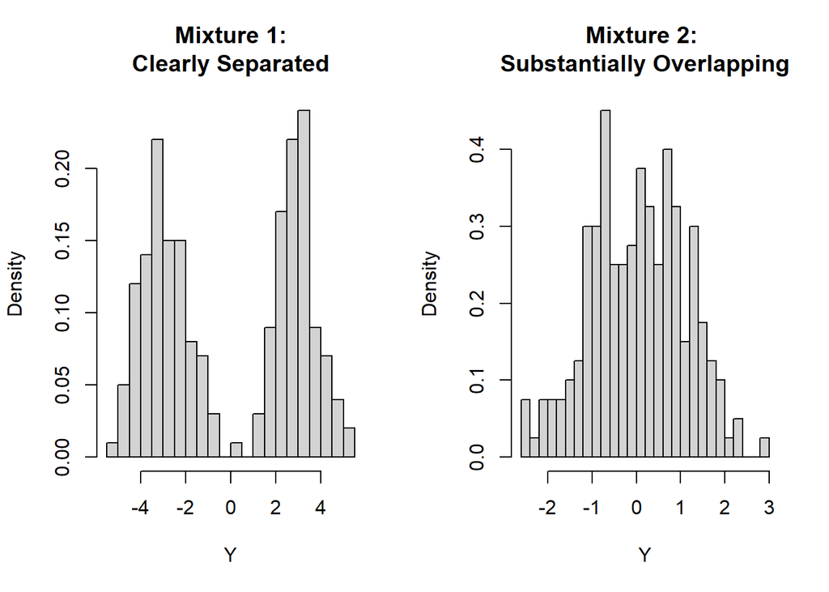

```r
simulate_mixture <- function(n, mu1, mu2, sigma2, pi) {

  # Generate component allocations
  z <- ifelse(runif(n) < pi, 1L, 2L)

  # Generate observations from their components
  y <- rnorm(n, mean = ifelse(z == 1, mu1, mu2), sd = sqrt(sigma2)  )

  return(list(y = y, z = z))
}


set.seed(123)

# Mixture 1: Clearly separated
data_sep <- simulate_mixture(
  n = 200,
  mu1 = -3,
  mu2 = 3,
  sigma2 = 1,
  pi = 0.5
)

# Mixture 2: Overlapping
data_overlap <- simulate_mixture(
  n = 200,
  mu1 = -0.5,
  mu2 = 0.5,
  sigma2 = 1,
  pi = 0.5
)

par(mfrow = c(1, 2))

hist(data_sep$y,
     breaks = 25,
     main = "Mixture 1:\nClearly Separated",
     xlab = "Y",
     probability = TRUE)

hist(data_overlap$y,
     breaks = 25,
     main = "Mixture 2: \nSubstantially Overlapping",
     xlab = "Y",
     probability = TRUE)
```

```r
par(mfrow = c(1, 1))
```

On the mixture 1, two populations create two peaks. So the observations provide strong information about their allocations. On the mixture 2, populations produce one heavily overlapping mixture. So observed data provide weaker information about the separate component means and allocations.

In the mixture 1, an observation of $-3$ is very likely to belong to component 1, while $+3$ is very likely to belong to component 2. But in mixture 2, an observation of $0$ is equally likely to have come from either component. Therefore the mixture 2, which is substantial overlap case is the more difficult MCMC mixing.

```r
# Initial values for the eight chains
initial_values <- list(
  c(-0.5, 0.5),
  c(0.5, -0.5),
  c(-3, 3),
  c(3, -3)
)

run_chains <- function(y, n_iter = 12000) {

  chains <- vector("list", 4)

  for (j in 1:4) {

    chains[[j]] <- gibbs_sampler(
      y = y,
      n_iter = n_iter,
      m0 = 0,
      s0 = 5,
      a = 1,
      b = 1,
      alpha0 = 2,
      beta0 = 1,
      mu1_init = initial_values[[j]][1],
      mu2_init = initial_values[[j]][2],
      pi_init = 0.5,
      sigma2_init = 1
    )
  }

  return(chains)
}

#run both simulations
set.seed(111)
chains_sep <- run_chains(data_sep$y)

set.seed(222)
chains_overlap <- run_chains(data_overlap$y)

#Remove burn in
burnin <- 2000

keep_sep <- lapply(chains_sep, function(x) {x$draws[-(1:burnin), ]})
keep_overlap <- lapply(chains_overlap, function(x) {x$draws[-(1:burnin), ]})
```

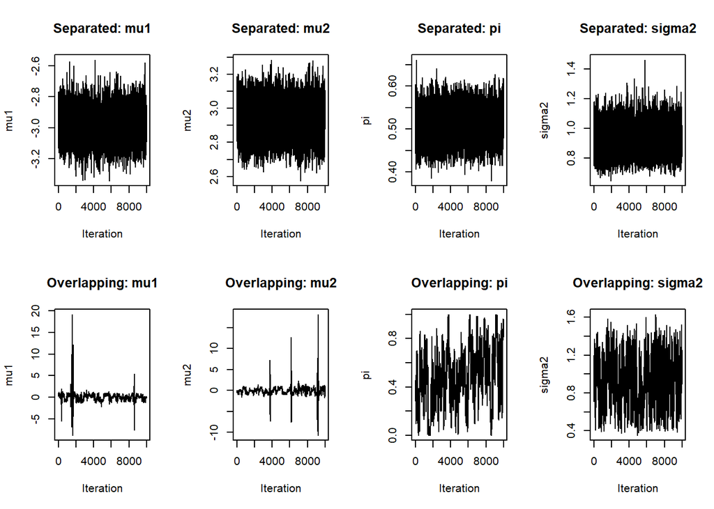

```r
par(mfrow = c(2, 4))

# Clearly separated
for (parameter in c("mu1", "mu2", "pi", "sigma2")) {
  plot(
    keep_sep[[1]][[parameter]],
    type = "l",
    main = paste("Separated:", parameter),
    xlab = "Iteration",
    ylab = parameter
  )
}

# Overlapping
for (parameter in c("mu1", "mu2", "pi", "sigma2")) {
  plot(
    keep_overlap[[1]][[parameter]],
    type = "l",
    main = paste("Overlapping:", parameter),
    xlab = "Iteration",
    ylab = parameter
  )
}
```

```r
par(mfrow = c(1, 1))
```

On clearly separated case $\mu_1,\mu_2$, $\pi$, $\sigma^2$ seems to be concentrated around stable values.

On Overlapping case $\mu_1,\mu_2$ seems to be stay relatively close to zero, but there are several very large spikes. On $\pi$, mixing proportion moves over a wide range compare to the clearly separated case. but $\sigma^2$ seems to be concentrated around stable value.

```r
plot_chains <- function(chains, parameter, title) {

  values <- lapply(chains, function(x) x[[parameter]])

  plot(values[[1]], type = "l",
       ylim = range(unlist(values)),
       col = 1,
       main = title,
       xlab = "Iteration",
       ylab = parameter)

  for (j in 2:length(values)) {
    lines(values[[j]], col = j)
  }

  legend("topright",
         legend = paste("Chain", 1:length(values)),
         col = seq_along(values),
         lty = 1,
         cex = 0.8)
}
```

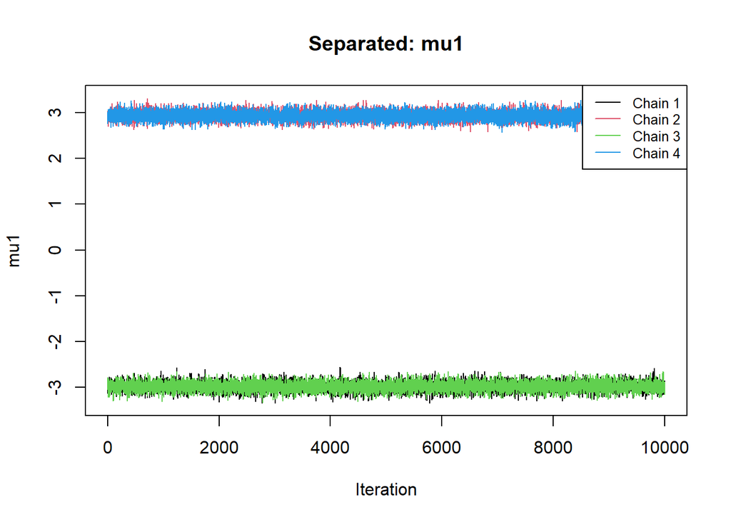

```r
plot_chains(
  keep_sep,
  parameter = "mu1",
  title = "Separated: mu1"
)
```

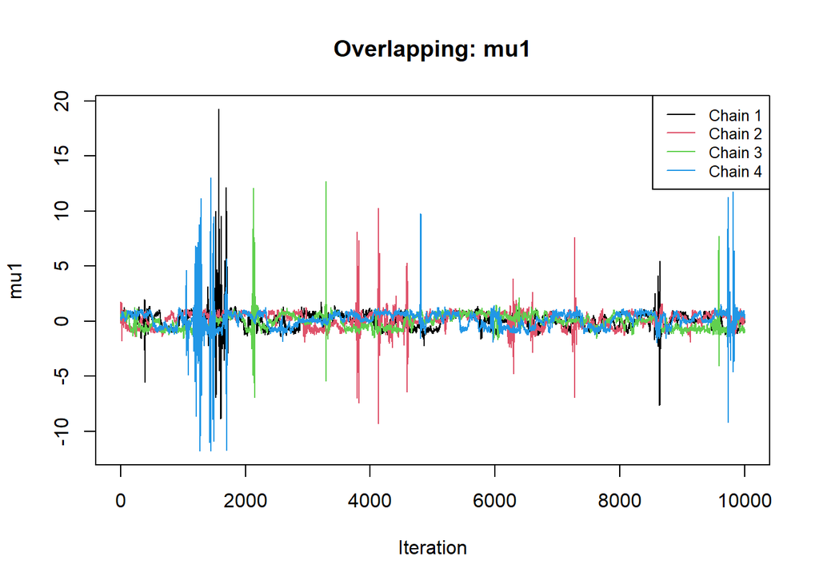

```r
plot_chains(
  keep_overlap,
  parameter = "mu1",
  title = "Overlapping: mu1"
)
```

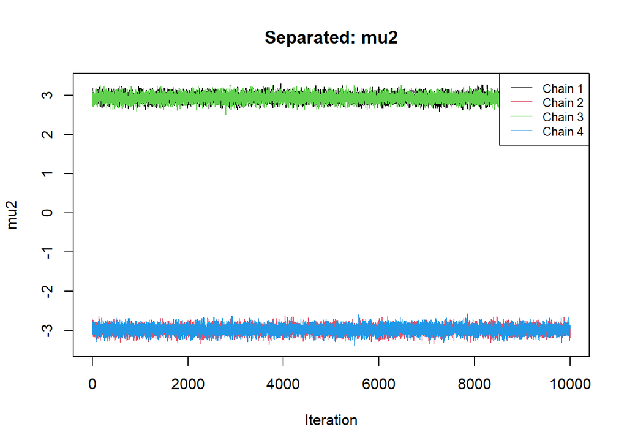

```r
plot_chains(
  keep_sep,
  parameter = "mu2",
  title = "Separated: mu2"
)
```

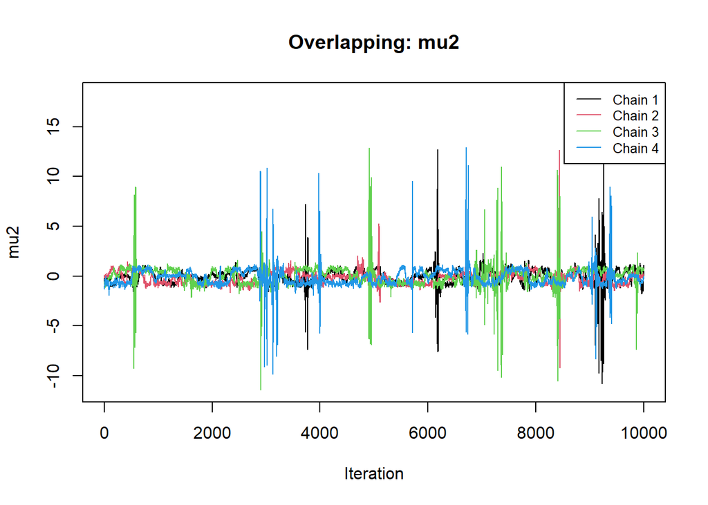

```r
plot_chains(
  keep_overlap,
  parameter = "mu2",
  title = "Overlapping: mu2"
)
```

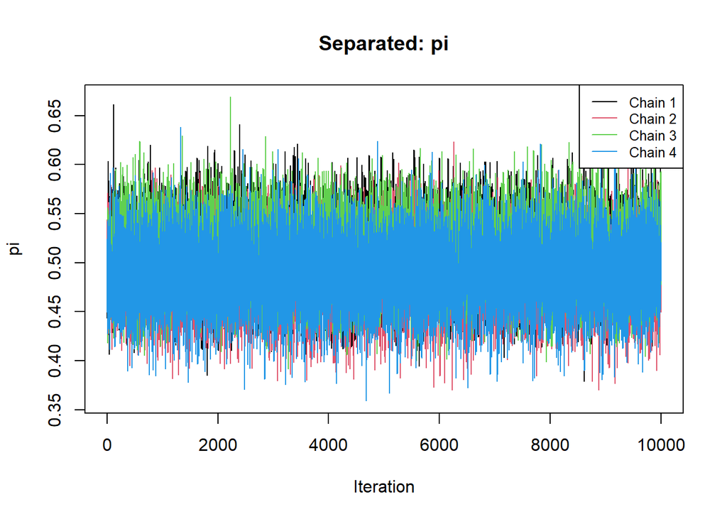

```r
plot_chains(
  keep_sep,
  parameter = "pi",
  title = "Separated: pi"
)
```

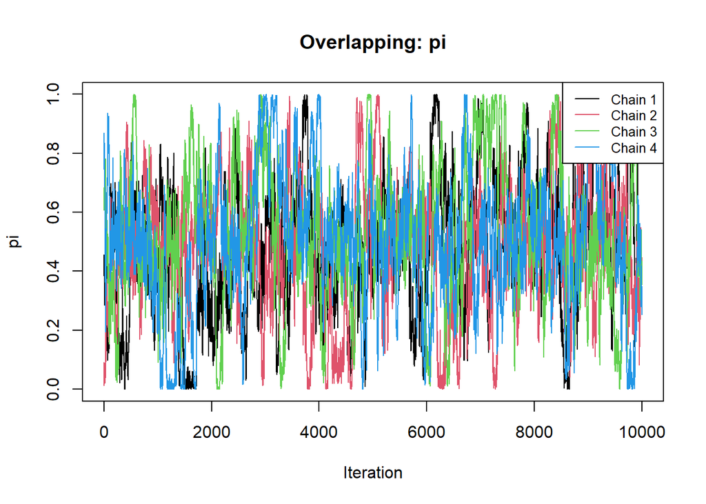

```r
plot_chains(
  keep_overlap,
  parameter = "pi",
  title = "Overlapping: pi"
)
```

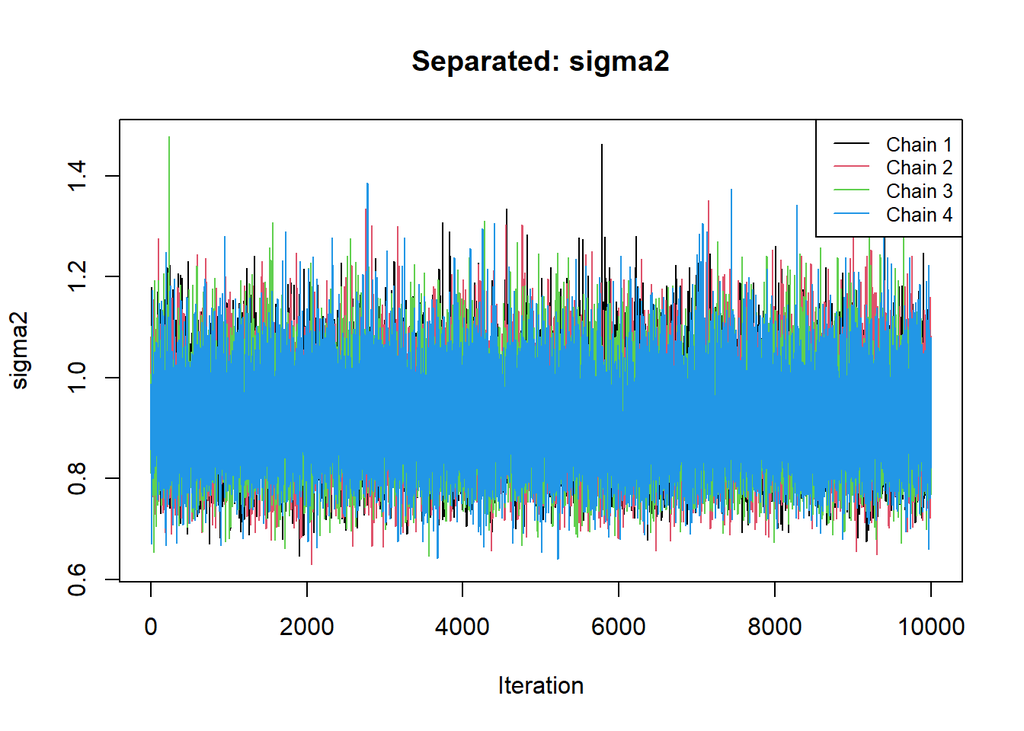

```r
plot_chains(
  keep_sep,
  parameter = "sigma2",
  title = "Separated: sigma2"
)
```

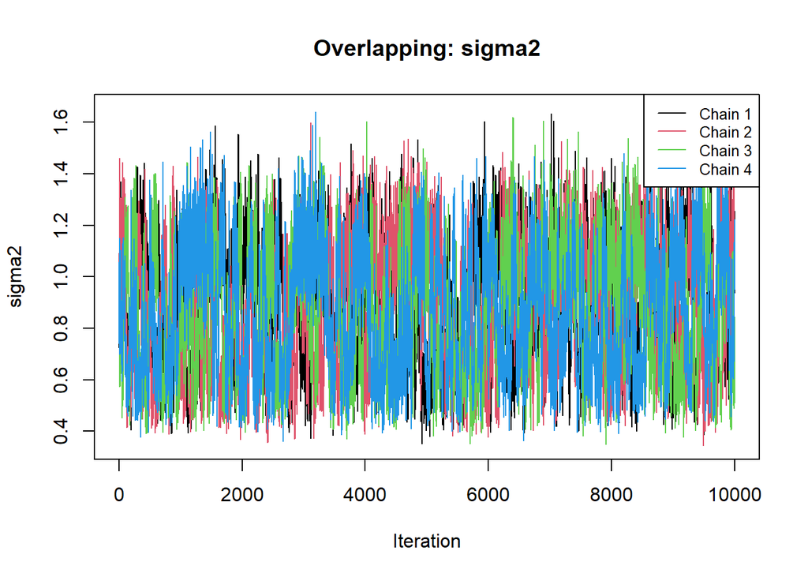

```r
plot_chains(
  keep_overlap,
  parameter = "sigma2",
  title = "Overlapping: sigma2"
)
```

#Part C

#Q1

```r
data_sep_c <- simulate_mixture(
  n = 200,
  mu1 = -3,
  mu2 = 3,
  sigma2 = 1,
  pi = 0.3
)
#change the pi to 0.3, so that it make it easier to identify the  label switching

set.seed(111)
chains_sep_c <- run_chains(data_sep_c$y)

keep_sep_c <- lapply(chains_sep_c, function(x) {x$draws[-(1:burnin), ]})
```

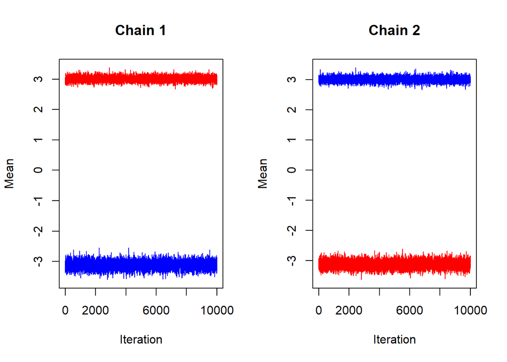

```r
#Label switching for means

draws <- chains_sep_c[[1]]$draws

burnin <- 2000
draws <- draws[-(1:burnin), ]

par(mfrow = c(1, 2))

for (j in 1:2) {

  d <- chains_sep_c[[j]]$draws
  d <- d[-(1:burnin), ]

  plot(d$mu1,
       type = "l",
       col = "blue",
       ylim = range(d$mu1, d$mu2),
       main = paste("Chain", j),
       xlab = "Iteration",
       ylab = "Mean")

  lines(d$mu2, col = "red")


}
```

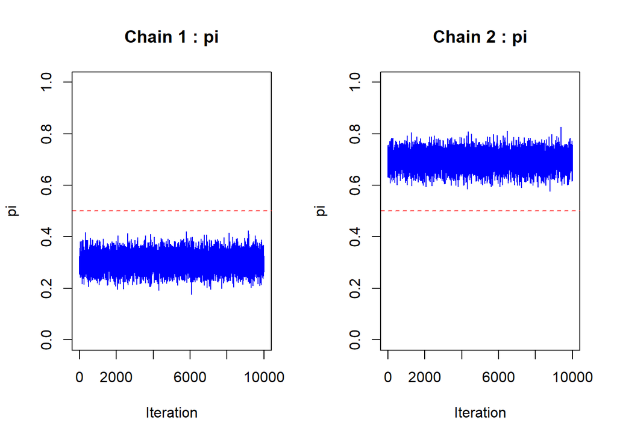

```r
#Label switching for pi

par(mfrow = c(1, 2))

for (j in 1:2) {

  d <- chains_sep_c[[j]]$draws
  d <- d[-(1:burnin), ]

  plot(
    d$pi,
    type = "l",
    col = "blue",
    ylim = c(0, 1),
    main = paste("Chain", j, ": pi"),
    xlab = "Iteration",
    ylab = "pi"
  )

  abline(h = 0.5, col = "red", lty = 2)
}
```

When $\mu_1\approx-3$ and $\mu_2\approx3$,$\pi$ is around 0.3. When $\mu_1\approx3$ and $\mu_2\approx-3$, $\pi$ is around 0.7. around 0.7. So that when the label switching occurs within the chain, the two traces have been exchanged their positions.

Because the Gibbs sampler can exchange the labels of the two components, even though the overall mixture distribution remains unchanged, ordinary posterior summaries can be misleading. When we calculate posterior means using samples from different labelling arrangements, we may average values from the lower mean and higher mean components together. As a result, the posterior means may not accurately represent the individual components.

Take the two components true parameters as:
$$\mu_1=-3,\qquad \mu_2=3,\qquad \pi=0.3$$
This means, Component 1 has mean $-3$ and weight 0.3. and Component 2 has mean $3$ and weight 0.7. But the Gibbs sampler also can produce:
$$\mu_1=3,\qquad \mu_2=-3,\qquad \pi=0.7$$
These two sets of parameters describe exactly the same mixture distribution. Only the labels have changed.

Now if we calculate the posterior mean of each parameter.

For $\mu_1$:
$$E(\mu_1\mid y)\approx\frac{-3-3+3+3}{4}$$
$$E(\mu_1\mid y)\approx0$$

For $\mu_2$:
$$E(\mu_2\mid y)\approx\frac{3+3-3-3}{4}$$
$$E(\mu_2\mid y)\approx0$$

For $\pi$:
$$E(\pi\mid y)\approx\frac{0.3+0.3+0.7+0.7}{4}$$
$$\boxed{E(\pi\mid y)\approx0.5}$$

Our posterior summaries suggest:
$$\mu_1\approx0,\qquad\mu_2\approx0,\qquad\pi\approx0.5$$

But the actual mixture contains:
$$\mu_1=-3,\qquad\mu_2=3,\qquad\pi=0.3$$

#Q3: Which posterior quantities remain meaningful without assigning fixed labels to the components?

1)Overall mixture mean
$$E(Y)=\pi\mu_1+(1-\pi)\mu_2$$

after switching the label
$$E(Y)=(1-\pi)\mu_2+\pi\mu_1$$
which is the same.

2)Overall mixture variance

Even we switch the labels, neither $\pi(1-\pi)$ nor $(\mu_1-\mu_2)^2$ changes
$$\operatorname{Var}(Y)=
\sigma^2+\pi(1-\pi)(\mu_1-\mu_2)^2$$

3)Mixture density

Switching the label will not change the total density
$$f(y)=\pi f_1(y)+(1-\pi)f_2(y)$$

#Q4

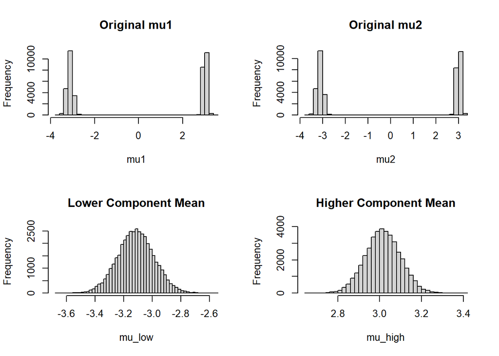

```r
all_draws <- do.call(
  rbind,
  lapply(chains_sep_c, function(x) {
    x$draws[-(1:burnin), ]
  })
)


# Post-process posterior samples
ordered_draws <- data.frame(

  mu_low = pmin(all_draws$mu1, all_draws$mu2),
  mu_high = pmax(all_draws$mu1, all_draws$mu2),

  pi_low = ifelse(
    all_draws$mu1 < all_draws$mu2,
    all_draws$pi,
    1 - all_draws$pi
  ),

  sigma2 = all_draws$sigma2
)

#plot

par(mfrow = c(2, 2))

hist(
  all_draws$mu1,
  breaks = 50,
  main = "Original mu1",
  xlab = "mu1"
)

hist(
  all_draws$mu2,
  breaks = 50,
  main = "Original mu2",
  xlab = "mu2"
)

hist(
  ordered_draws$mu_low,
  breaks = 50,
  main = "Lower Component Mean",
  xlab = "mu_low"
)

hist(
  ordered_draws$mu_high,
  breaks = 50,
  main = "Higher Component Mean",
  xlab = "mu_high"
)
```

```r
par(mfrow = c(1, 1))


#Posterior means

# Before post-processing
colMeans(all_draws)
```

```
##         mu1         mu2          pi      sigma2
## -0.04966139 -0.04831429  0.50003988  0.97704873
```

```r
# After post-processing
colMeans(ordered_draws)
```

```
##     mu_low    mu_high     pi_low     sigma2
## -3.1136494  3.0156737  0.3018300  0.9770487
```

# Part D: Application to the Faithful Data

## 1. Data, prior and sampler runs

The data are standardized, so that the prior of Part A can be used on a common scale. All results below are transformed back to minutes.

```r
data(faithful)
y <- faithful$eruptions
n <- length(y)

# Standardize; the original mean and sd are kept to transform results back
y_mean <- mean(y)
y_sd <- sd(y)
ys <- (y - y_mean) / y_sd

cat("n =", n)
```

```
## n = 272
```

```r
cat("Mean and sd of eruptions (minutes):", round(c(y_mean, y_sd), 3))
```

```
## Mean and sd of eruptions (minutes): 3.488 1.141
```

The prior is set on the standardized scale: $\mu_1, \mu_2 \sim N(0, 5^2)$, $\pi \sim \text{Beta}(1, 1)$ and $\sigma^2 \sim \text{InvGamma}(2, 1)$. These priors are weakly informative: the standardized data lie roughly between $-1.7$ and $1.4$, so $N(0, 5^2)$ for the means covers the data range several times.

```r
m0 <- 0
s0 <- 5
a <- 1
b <- 1
alpha0 <- 2
beta0 <- 1
```

Four chains are run from different starting values. The starting means are placed on both sides of zero and are swapped between chains, so that the chains start in both labellings. The starting values of $\pi$ and $\sigma^2$ also differ.

```r
n_iter <- 12000
burnin <- 2000

inits <- data.frame(
  mu1 = c(-1, 1, -2, 2),
  mu2 = c(1, -1, 2, -2),
  pi = c(0.5, 0.3, 0.7, 0.5),
  sigma2 = c(1, 0.5, 2, 1)
)

set.seed(1)
chains <- lapply(1:4, function(j) {
  gibbs_sampler(ys, n_iter = n_iter, m0 = m0, s0 = s0, a = a, b = b,
                alpha0 = alpha0, beta0 = beta0,
                mu1_init = inits$mu1[j], mu2_init = inits$mu2[j],
                pi_init = inits$pi[j], sigma2_init = inits$sigma2[j])
})
```

## 2. Label switching in the output

Before any post-processing, each chain is checked for label switching. A swap means that $\mu_1 > \mu_2$ at an iteration.

```r
raw_summary <- t(sapply(chains, function(ch) {
  d <- ch$draws[-(1:burnin), ]
  swap <- d$mu1 > d$mu2
  c(mu1 = mean(d$mu1), mu2 = mean(d$mu2), pi = mean(d$pi),
    share_mu1_above_mu2 = mean(swap),
    label_changes = sum(diff(swap) != 0))
}))
rownames(raw_summary) <- paste("chain", 1:4)
round(raw_summary, 3)
```

```
##            mu1    mu2    pi share_mu1_above_mu2 label_changes
## chain 1 -1.262  0.709 0.361                   0             0
## chain 2  0.709 -1.262 0.639                   1             0
## chain 3 -1.261  0.710 0.361                   0             0
## chain 4  0.709 -1.261 0.639                   1             0
```

Within each chain the labelling never changes (0 label changes). Chains 2 and 4 are in the swapped labelling compared with chains 1 and 3 ($\mu_1 > \mu_2$ and $\pi \approx 0.64$ instead of $0.36$), because they started from swapped initial values. Both labellings describe the same mixture: means of $-1.26$ and $0.71$ on the standardized scale, with weights $0.36$ and $0.64$. Pooling the chains without relabelling would mix the two components, as discussed in Part C. Because the two groups are well separated, no chain switches labelling.

The labels are arbitrary, so the draws are relabelled such that component “low” is always the one with the smaller mean. This puts all chains on the same labelling. In every iteration with $\mu_1 > \mu_2$:

- the two means are swapped, so that $\mu_{\text{low}} = \mu_2$ and $\mu_{\text{high}} = \mu_1$;
- the weight of the low component is $1-\pi$ instead of $\pi$, because $\pi$ is the weight of component 1, which is now the high component;
- the allocations $Z_i$ are switched between 1 and 2, so that they refer to the new labels.

Iterations with $\mu_1 < \mu_2$ are left unchanged. After this step, all four chains describe the same two components.

```r
relabel <- function(ch, burnin) {
  d <- ch$draws[-(1:burnin), ]
  Z <- ch$Z[-(1:burnin), ]
  swap <- d$mu1 > d$mu2
  Z[swap, ] <- 3L - Z[swap, ]
  list(
    draws = data.frame(mu_low = pmin(d$mu1, d$mu2),
                       mu_high = pmax(d$mu1, d$mu2),
                       pi_low = ifelse(swap, 1 - d$pi, d$pi),
                       sigma2 = d$sigma2),
    # Posterior probability that observation i belongs to the high component
    p_high = colMeans(Z == 2)
  )
}

# Transform back to the original scale (minutes)
to_orig <- function(d) {
  data.frame(mu_low = d$mu_low * y_sd + y_mean,
             mu_high = d$mu_high * y_sd + y_mean,
             pi_low = d$pi_low,
             sigma = sqrt(d$sigma2) * y_sd)
}

rel <- lapply(chains, relabel, burnin = burnin)
ord <- lapply(rel, function(r) to_orig(r$draws))
pooled <- do.call(rbind, ord)
```

## 3. MCMC performance and posterior summaries

Trace plots of the relabelled chains, original scale:

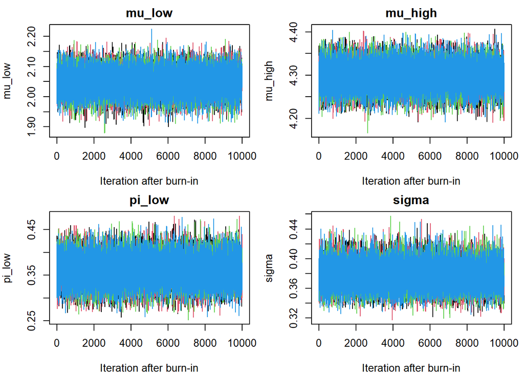

```r
par(mfrow = c(2, 2), mar = c(4, 4, 2, 1))
for (p in c("mu_low", "mu_high", "pi_low", "sigma")) {
  vals <- sapply(ord, function(d) d[[p]])
  matplot(vals, type = "l", lty = 1, col = 1:4, main = p,
          xlab = "Iteration after burn-in", ylab = p)
}
```

The potential scale reduction factor $\hat R$ (Gelman–Rubin, computed on the four relabelled chains) and the effective sample size (ESS, summed over the chains, from the autocorrelation of each chain truncated at the first negative value) are computed directly.

```r
rhat <- function(x) {
  # x: matrix with one column per chain
  m <- ncol(x)
  k <- nrow(x)
  W <- mean(apply(x, 2, var))
  B <- k * var(colMeans(x))
  sqrt(((k - 1) / k * W + B / k) / W)
}

ess <- function(x) {
  k <- length(x)
  rho <- acf(x, lag.max = 1000, plot = FALSE)$acf[-1]
  cut <- which(rho < 0)[1] - 1
  if (is.na(cut)) cut <- length(rho)
  k / (1 + 2 * sum(rho[seq_len(cut)]))
}

pars <- c("mu_low", "mu_high", "pi_low", "sigma")
summ <- t(sapply(pars, function(p) {
  x <- sapply(ord, function(d) d[[p]])
  c(mean = mean(x), sd = sd(x),
    q2.5 = unname(quantile(x, 0.025)), q97.5 = unname(quantile(x, 0.975)),
    Rhat = rhat(x), ESS = sum(apply(x, 2, ess)))
}))
summ_out <- round(summ, 3)
summ_out[, "ESS"] <- round(summ[, "ESS"])
knitr::kable(summ_out)
```

|  | mean | sd | q2.5 | q97.5 | Rhat | ESS |
| --- | --- | --- | --- | --- | --- | --- |
| mu_low | 2.048 | 0.039 | 1.972 | 2.124 | 1 | 36086 |
| mu_high | 4.297 | 0.029 | 4.241 | 4.353 | 1 | 37964 |
| pi_low | 0.361 | 0.029 | 0.305 | 0.419 | 1 | 38646 |
| sigma | 0.377 | 0.016 | 0.346 | 0.411 | 1 | 36967 |

The relabelled chains agree closely, and the traces overlap without any drift. $\hat R$ is 1.00 for all four parameters. The effective sample sizes are above 36,000 out of 40,000 stored draws, so the draws are almost uncorrelated.

The table also gives the posterior means, standard deviations and 95% credible intervals of the relabelled parameters, in minutes. Component “low” has the smaller mean, “high” the larger one, and $\sigma$ is the common standard deviation of the two components. The lower component has mean 2.05 minutes (95% interval [1.97, 2.12]) and weight 0.36 ([0.305, 0.419]). The upper component has mean 4.30 minutes ([4.24, 4.35]) and weight 0.64. The common standard deviation is 0.38 minutes ([0.35, 0.41]).

## 4. Fitted mixture compared with the data

The fitted density is computed for every (thinned) posterior draw as $\pi f_{\text{low}} + (1-\pi) f_{\text{high}}$. This density does not depend on the labelling. The plot shows its posterior mean with pointwise 95% bands, together with the histogram and a kernel density estimate of the data.

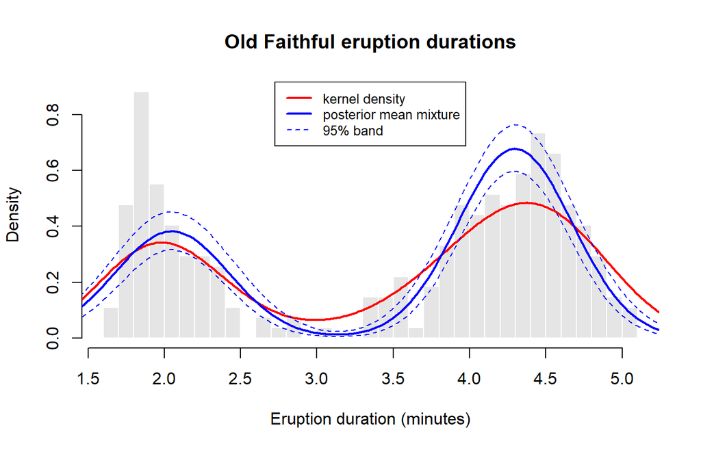

```r
grid <- seq(1, 6, length.out = 300)
idx <- seq(1, nrow(pooled), by = 20)

dens <- sapply(idx, function(t) {
  pooled$pi_low[t] * dnorm(grid, pooled$mu_low[t], pooled$sigma[t]) +
    (1 - pooled$pi_low[t]) * dnorm(grid, pooled$mu_high[t], pooled$sigma[t])
})
dens_mean <- rowMeans(dens)
dens_lo <- apply(dens, 1, quantile, probs = 0.025)
dens_hi <- apply(dens, 1, quantile, probs = 0.975)

hist(y, breaks = 30, probability = TRUE, col = "gray90", border = "white",
     main = "Old Faithful eruption durations", xlab = "Eruption duration (minutes)")
lines(density(y), col = "red", lwd = 2)
lines(grid, dens_mean, col = "blue", lwd = 2)
lines(grid, dens_lo, col = "blue", lty = 2)
lines(grid, dens_hi, col = "blue", lty = 2)

legend("top",
       c("kernel density", "posterior mean mixture", "95% band"),
       col = c("red", "blue", "blue"), lty = c(1, 1, 2),
       lwd = c(2, 2, 1), bg = "white", cex = 0.8)
```

The posterior mean mixture has its two peaks at about 2.0 and 4.3 minutes, in line with the two modes of the histogram, and the density between them is close to zero. The kernel density estimate has lower peaks and a higher valley than the fitted mixture. The 95% band is narrow, but it only reflects the uncertainty in the parameters, not how well the model fits. The fit is not perfect: the highest histogram bar of the short eruptions (near 1.8 minutes) is well above the fitted density, the mixture puts some density below the shortest observed duration (about 1.6 minutes), and it lies below the histogram on the left side of the long group, between about 3.3 and 3.6 minutes.

## 5. Uncertainty about the allocation

The posterior probability that observation $i$ belongs to the high component is the share of draws that allocate it to that component, after relabelling.

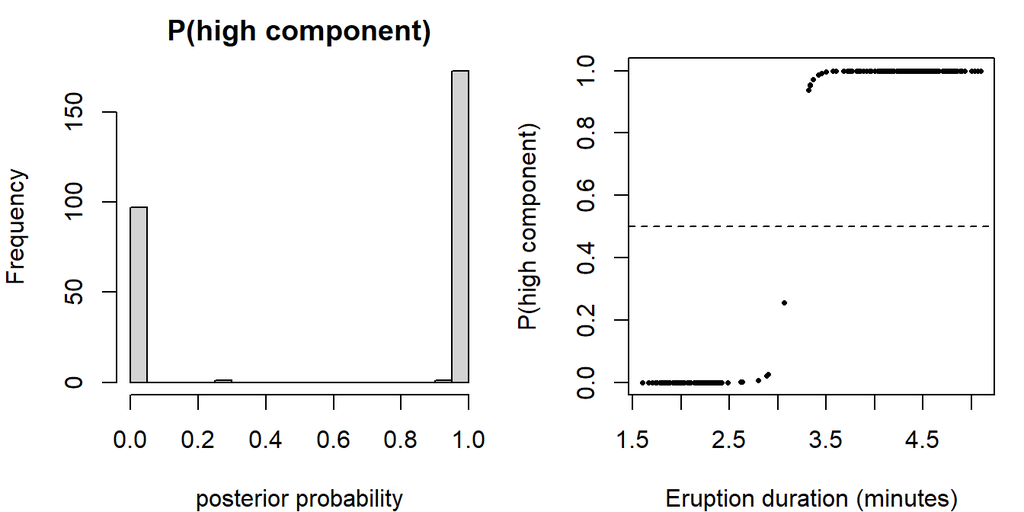

```r
p_high <- rowMeans(sapply(rel, function(r) r$p_high))

par(mfrow = c(1, 2), mar = c(4, 4, 2, 1))
hist(p_high, breaks = 20, main = "P(high component)", xlab = "posterior probability")
plot(y, p_high, pch = 16, cex = 0.5, xlab = "Eruption duration (minutes)",
     ylab = "P(high component)")
abline(h = 0.5, lty = 2)
```

```r
cat("Observations with P(high) > 0.5:", sum(p_high > 0.5))
```

```
## Observations with P(high) > 0.5: 174
```

```r
cat("Observations with 0.05 < P(high) < 0.95:", sum(p_high > 0.05 & p_high < 0.95))
```

```
## Observations with 0.05 < P(high) < 0.95: 2
```

```r
cat("Range of eruption durations with 0.05 < P(high) < 0.95:",
    round(range(y[p_high > 0.05 & p_high < 0.95]), 2))
```

```
## Range of eruption durations with 0.05 < P(high) < 0.95: 3.07 3.32
```

174 of the 272 observations have a posterior probability above 0.5 of belonging to the upper component, which agrees with the estimated weight of 0.64. Only 2 observations have a probability between 0.05 and 0.95 (the two thresholds are an arbitrary choice). Their durations are 3.07 and 3.32 minutes, in the gap between the two groups. The uncertainty about the allocation is therefore limited to the boundary between the components.

## 6. Is the two-component Gaussian mixture adequate?

A posterior predictive check is used. Data sets of the same size are simulated from the fitted model (parameters drawn from the posterior, then allocations and observations simulated), and the sample skewness and excess kurtosis are compared with the observed values. The posterior predictive p-value is the share of replicated values at least as large as the observed one.

```r
rep_data <- function(t) {
  z <- runif(n) < pooled$pi_low[t]
  rnorm(n, ifelse(z, pooled$mu_low[t], pooled$mu_high[t]), pooled$sigma[t])
}
skew <- function(x) mean((x - mean(x))^3) / sd(x)^3
kurt <- function(x) mean((x - mean(x))^4) / sd(x)^4 - 3

set.seed(1)
rep_idx <- sample(nrow(pooled), 500)
stat_rep <- t(sapply(rep_idx, function(t) {
  yr <- rep_data(t)
  c(skew = skew(yr), kurt = kurt(yr))
}))
stat_obs <- c(skew = skew(y), kurt = kurt(y))

ppp <- colMeans(sweep(stat_rep, 2, stat_obs, ">="))
round(rbind(observed = stat_obs, ppp = ppp), 3)
```

```
##            skew   kurt
## observed -0.414 -1.512
## ppp       0.318  0.866
```

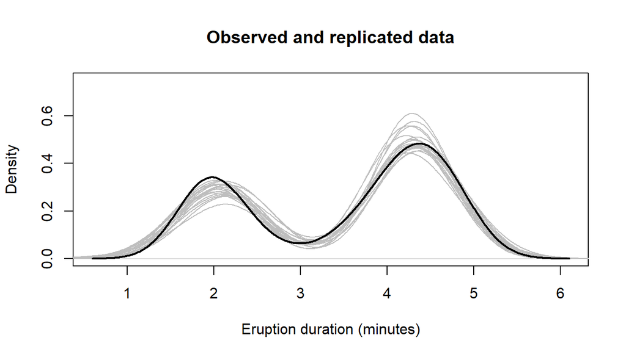

```r
# Density of the data against densities of a few replicated data sets
plot(density(y), lwd = 2, main = "Observed and replicated data",
     xlab = "Eruption duration (minutes)",
     ylim = c(0, 0.75))
for (t in rep_idx[1:20]) lines(density(rep_data(t)), col = "gray")
lines(density(y), lwd = 2)
```

The observed skewness ($-0.41$) and excess kurtosis ($-1.51$) are not extreme under the fitted model: the posterior predictive p-values are 0.32 and 0.87. The kurtosis of the data is in the lower part of the replicated values, so the replicated data have somewhat heavier tails. The plot of the replicated densities shows the same pattern. The two modes and the gap between them are reproduced, but the observed density is higher than all 20 replicated densities at the peak of the short eruptions, and the replicates have more mass below 1.5 minutes. These two statistics are only a rough check.

## 7. Interpretation of the components

The lower component has mean 2.05 minutes and weight 0.36, and the upper component has mean 4.30 minutes and weight 0.64, with a common standard deviation of 0.38 minutes. Chains 2 and 4 were in the swapped labelling, so these values are reported after relabelling the draws. Only 2 of the 272 observations have an uncertain allocation. The mixture is a useful description of the shape of the distribution, but this does not show that the eruptions come from two physically distinct populations.